# Explore Data, Visualize, and Build Predictive Models with the Titanic Dataset in R

Vietnamese version

Tran Trong Phuc

August 1, 2025

# 1 Tổng quan

## 1.1 Về tập dữ liệu

Dataset **Titanic** trên [Kaggle](https://www.kaggle.com/datasets/yasserh/titanic-dataset/data) là một trong những bộ dữ liệu học máy nổi tiếng và được sử dụng phổ biến để thực hành các kỹ thuật phân tích dữ liệu và học máy, đặc biệt là phân loại (classification). Dưới đây là phần sơ lược về dataset này:

| Cột | Kiểu dữ liệu | Mô tả |
| --- | --- | --- |
| `PassengerId` | `int` | Mã hành khách (duy nhất) |
| `Survived` | `int` (0 hoặc 1) | Sống sót (1) hoặc tử vong (0) |
| `Pclass` | `int` (1, 2, 3) | Hạng vé (1 = cao nhất, 3 = thấp nhất) |
| `Name` | `character` | Tên hành khách |
| `Sex` | `character` | Giới tính |
| `Age` | `numeric` | Tuổi |
| `SibSp` | `int` | Số anh/chị/em hoặc vợ/chồng đi cùng |
| `Parch` | `int` | Số cha/mẹ hoặc con đi cùng |
| `Ticket` | `character` | Mã vé |
| `Fare` | `numeric` | Giá vé |
| `Cabin` | `character` | Số phòng (thường bị thiếu nhiều) |
| `Embarked` | `character` (C, Q, S) | Cảng lên tàu: C = Cherbourg, Q = Queenstown, S = Southampton |

## 1.2 Mục tiêu

- Khám phá dữ liệu, trực quan hoá bằng các thư viện trong `R`.
- Sử dụng các mô hình học máy để phân loại tình trạng sống sót (Survived).

## 1.3 Chuẩn bị

**Gói lệnh**

```r
if (!require("pacman")) install.packages("pacman")
pacman::p_load("readr", "dplyr", "ggplot2", "corrplot",
              "skimr", "FNN", "randomForest")
```

**Dữ liệu**

```r
df <- read.csv("Titanic_Dataset.csv", header = TRUE)
df <- df %>% select(- PassengerId)
```

# 2 Khám phá và trực quan hoá

## 2.1 Dữ liệu thiếu

```r
skim_without_charts(df)
```

Data summary

| Name | df |
| --- | --- |
| Number of rows | 891 |
| Number of columns | 11 |
| _______________________ |  |
| Column type frequency: |  |
| character | 5 |
| numeric | 6 |
| ________________________ |  |
| Group variables | None |

**Variable type: character**

| skim_variable | n_missing | complete_rate | min | max | empty | n_unique | whitespace |
| --- | --- | --- | --- | --- | --- | --- | --- |
| Name | 0 | 1 | 12 | 82 | 0 | 891 | 0 |
| Sex | 0 | 1 | 4 | 6 | 0 | 2 | 0 |
| Ticket | 0 | 1 | 3 | 18 | 0 | 681 | 0 |
| Cabin | 0 | 1 | 0 | 15 | 687 | 148 | 0 |
| Embarked | 0 | 1 | 0 | 1 | 2 | 4 | 0 |

**Variable type: numeric**

| skim_variable | n_missing | complete_rate | mean | sd | p0 | p25 | p50 | p75 | p100 |
| --- | --- | --- | --- | --- | --- | --- | --- | --- | --- |
| Survived | 0 | 1.0 | 0.38 | 0.49 | 0.00 | 0.00 | 0.00 | 1 | 1.00 |
| Pclass | 0 | 1.0 | 2.31 | 0.84 | 1.00 | 2.00 | 3.00 | 3 | 3.00 |
| Age | 177 | 0.8 | 29.70 | 14.53 | 0.42 | 20.12 | 28.00 | 38 | 80.00 |
| SibSp | 0 | 1.0 | 0.52 | 1.10 | 0.00 | 0.00 | 0.00 | 1 | 8.00 |
| Parch | 0 | 1.0 | 0.38 | 0.81 | 0.00 | 0.00 | 0.00 | 0 | 6.00 |
| Fare | 0 | 1.0 | 32.20 | 49.69 | 0.00 | 7.91 | 14.45 | 31 | 512.33 |

```r
paste("Missing data rate:", paste0(round(177/891*100,2), "%"))
```

```
## [1] "Missing data rate: 19.87%"
```

## 2.2 Biểu đồ trực quan

### 2.2.1 Tỷ lệ sống sót

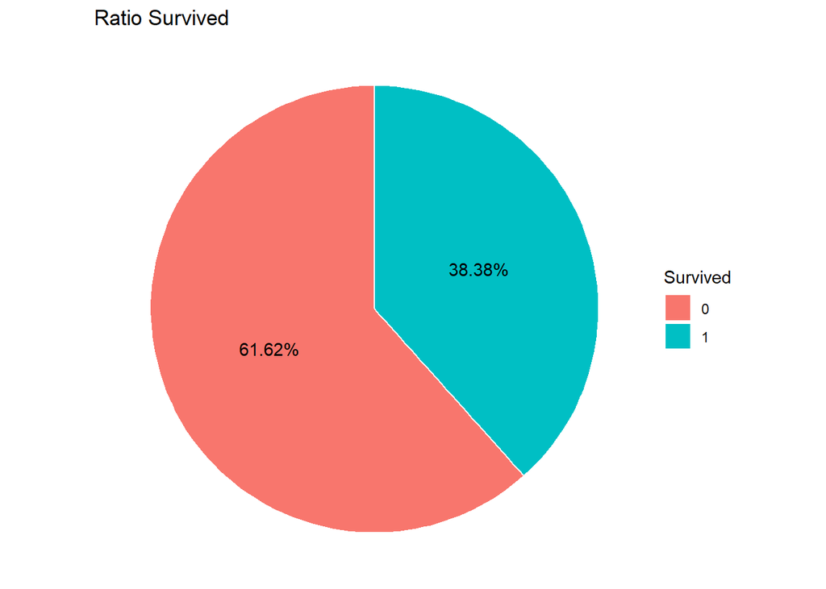

```r
df %>% select("Survived") %>%
  group_by(Survived) %>%
  count() %>% mutate(r = n/nrow(df)) %>%
  ggplot(aes(x = 2, y = r, fill = factor(Survived))) +
  geom_bar(stat = "identity", width = 1, color = "white") +
  coord_polar("y") +
  theme_void() +
  labs(title = "Ratio Survived", fill = "Survived") +
  geom_text(aes(label = paste0(round(r*100,2), "%")),
            position = position_stack(vjust = 0.5))
```

### 2.2.2 Hạng vé

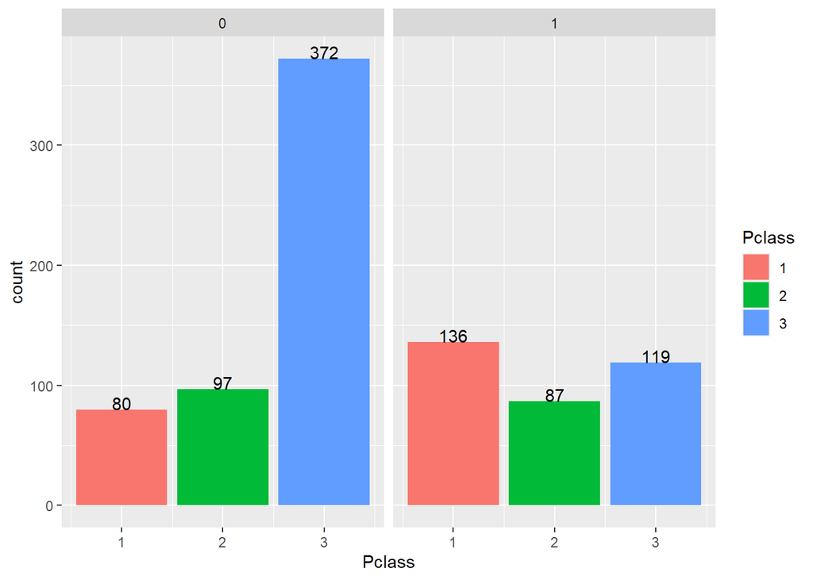

```r
df %>%
  ggplot(mapping = aes(x = Pclass, fill = factor(Pclass))) +
  geom_bar(position = "dodge") +
  geom_text(stat = 'count', aes(label = ..count..), vjust = 0)+
  facet_wrap(~Survived) +
  labs(fill = "Pclass")
```

**Nhận xét:** Khách hàng mua vé hạn nhất (`Pclass=1`) có số lượng sống sót cao nhất. Vé hạn ba (`Pclass=3`) có số lượng tử vong nhiều nhất.

### 2.2.3 Giới tính

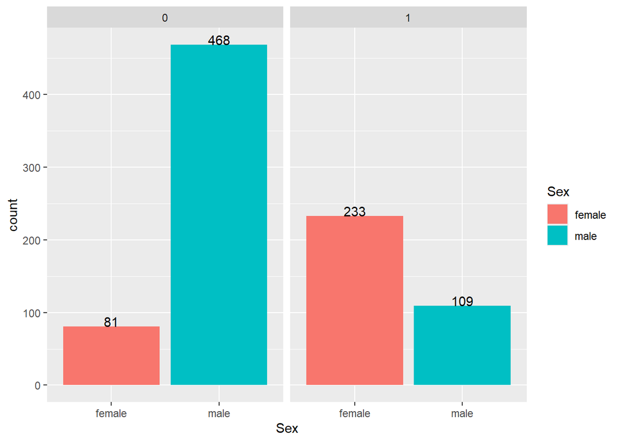

```r
df %>%
  ggplot(mapping = aes(x = Sex, fill = factor(Sex))) +
  geom_bar(position = "dodge") +
  geom_text(stat = 'count', aes(label = ..count..), vjust = 0)+
  facet_wrap(~Survived) +
  labs(fill = "Sex")
```

**Nhận xét:** Nữ giới có số lượng sống sót cao hơn, đối với nam giới thì ngược lại.

### 2.2.4 Tuổi

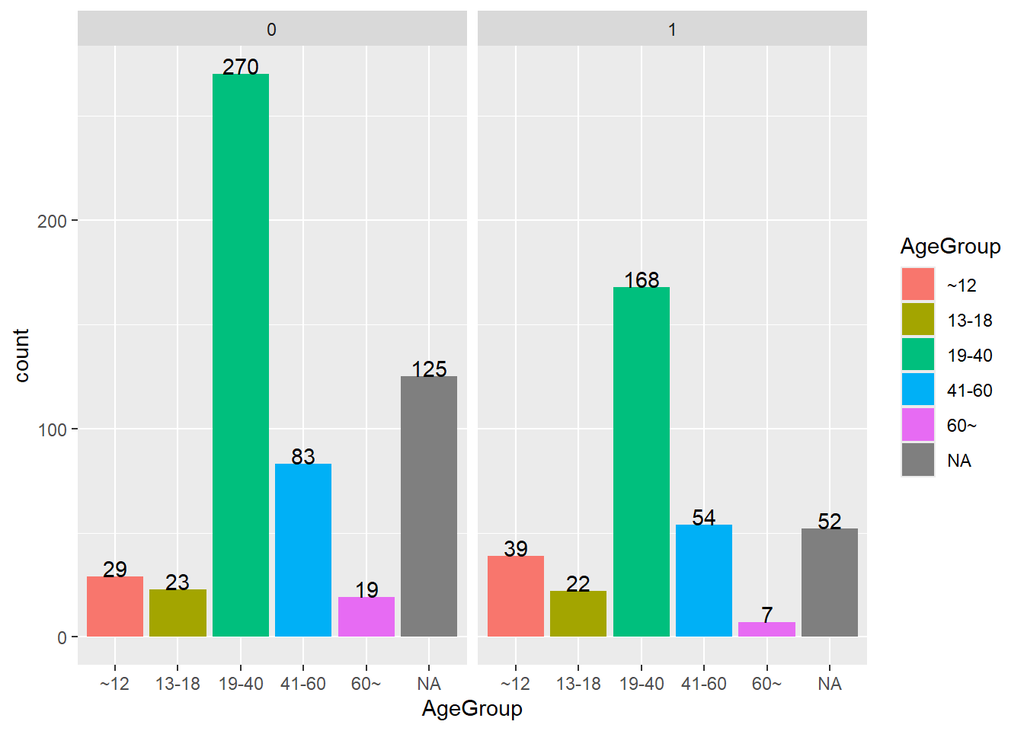

```r
df %>%
  mutate(AgeGroup = case_when(
    Age < 12 ~ "~12",
    Age >= 12 & Age < 18 ~ "13-18",
    Age >= 18 & Age < 40 ~ "19-40",
    Age >= 40 & Age < 60 ~ "41-60",
    Age >= 60 ~ "60~",
    TRUE ~ NA_character_
  )) %>% ggplot(aes(AgeGroup, fill = AgeGroup)) +
  geom_bar() +
  geom_text(stat = 'count', aes(label = ..count..), vjust = "bottom") +
  # theme(legend.title = element_blank(), legend.position = "none") +
  facet_wrap(~ Survived) +
  labs(fill = "AgeGroup")
```

### 2.2.5 Số người thân đi cùng

Bao gồm 2 biến `SibSp` và `Parch`

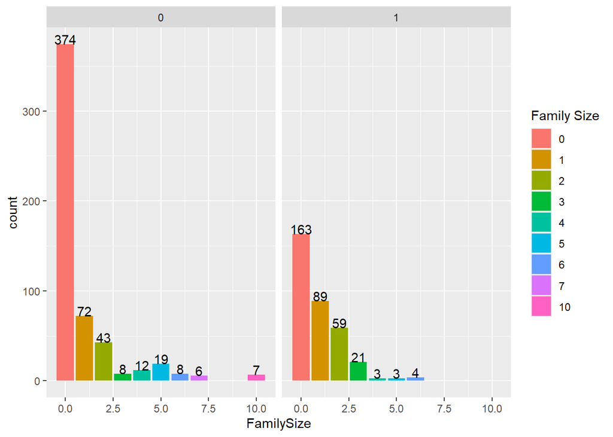

```r
df %>%
  mutate(FamilySize = SibSp + Parch) %>%
  ggplot(aes(FamilySize, fill = factor(FamilySize))) +
  geom_bar() +
  geom_text(stat = 'count', aes(label = ..count..), vjust = "bottom") +
  facet_wrap(~ Survived) +
  labs(fill = "Family Size")
```

**Nhận xét:** Đa phần hành khách không đi cùng người thân.

### 2.2.6 Cảng lên tàu

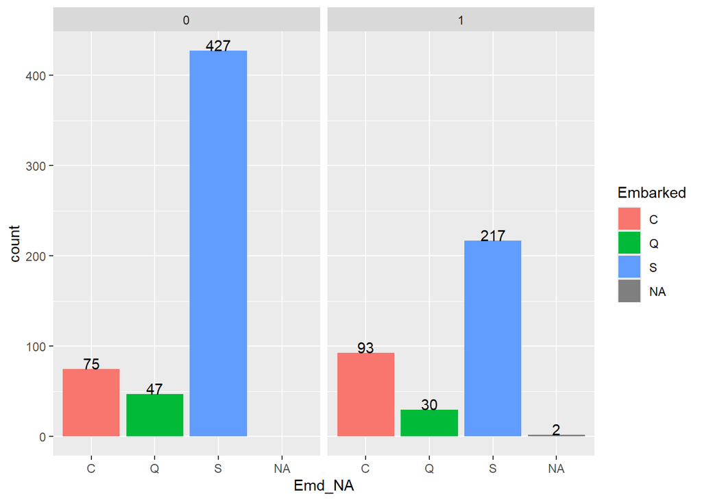

```r
df %>% mutate(Emd_NA = case_when(
  Embarked == "S" ~ "S",
  Embarked == "C" ~ "C",
  Embarked == "Q" ~ "Q",
  Embarked == "" ~ NA_character_
  )) %>%
  ggplot(mapping = aes(x = Emd_NA, fill = factor(Emd_NA))) +
  geom_bar() +
  geom_text(stat = 'count', aes(label = ..count..), vjust = "bottom") +
  facet_wrap(~ Survived) +
  labs(fill = "Embarked")
```

**Nhận xét:** Phần lớn hành khác đến từ cảng `S`-Southampton, nhưng tỷ lệ tử vong lại cao hơn các cảng khác.

### 2.2.7 Histograms

Trực quan tần số cho biến liến tục:

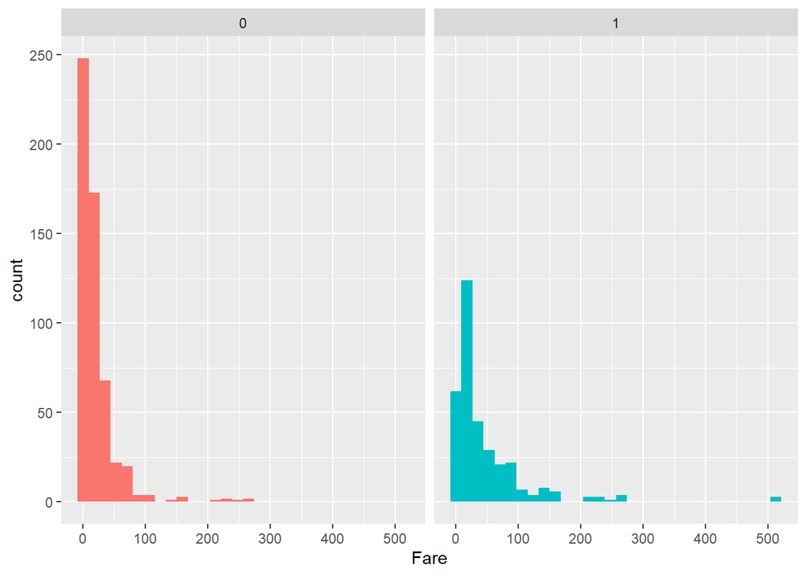

```r
df %>% ggplot(aes(x = Fare, fill = factor(Survived))) +
  geom_histogram() +
  theme(legend.title = element_blank(), legend.position = "none") +
  facet_wrap(~ Survived)
```

**Nhận xét:** Phần lớn hành khách chọn giá vé dưới 100 Bảng Anh.

### 2.2.8 Q-Q plot

Biểu đồ Q-Q (Quantile-Quantile) vị là một cách để hình dung độ lệch khỏi một phân phối xác suất cụ thể. Sau khi phân tích các biểu đồ này, việc áp dụng phép biến đổi toán học (như logarit) cho các mô hình như hồi quy tuyến tính thường có lợi.

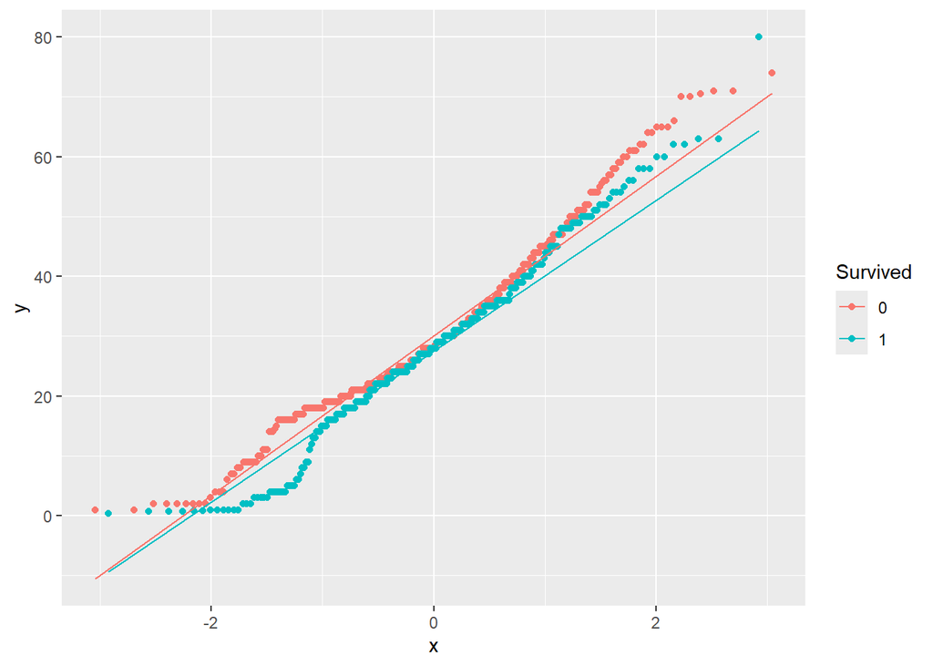

```r
df %>%
  ggplot(aes(sample = Age, colour = factor(Survived))) +
  stat_qq() + stat_qq_line() +
  labs(colour = "Survived")
```

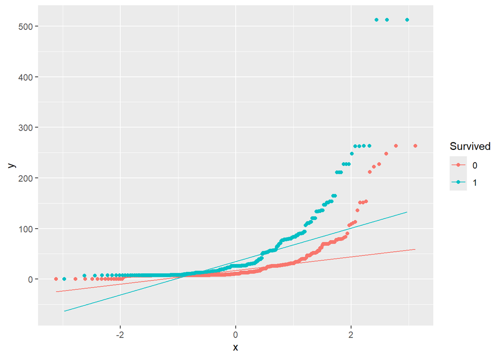

```r
df %>%
  ggplot(aes(sample = Fare, colour = factor(Survived))) +
  stat_qq() + stat_qq_line() +
  labs(colour = "Survived")
```

**Nhận xét:**

- Biến `Age` theo cả 2 tình trạng sống sót hay tử vong của biến `Survived` đều xấp xỉ dường chéo cho thấy biến xấp xỉ phân phối chuẩn.
- Biến `Fare` có các điểm có khoản cách rất xa so với đường chéo chỉ ra độ phân tán của biến rất cao, vậy nên biến không có phân phối chuẩn.